# Big Sur Plot Network

- Workbook libraries, styles and classes  
- Plot disturbance grouping  
- How many redwoods have died since plot implementation?  
- Comparing DBH to Canopy Height

### Import

```python
#libraries
import pandas as pd
import numpy as np
import seaborn as sns
import matplotlib.pyplot as plt
from scipy import stats
from scipy.stats import f_oneway
from scipy.stats import tukey_hsd
from scipy.stats import linregress
from IPython.display import display
import statsmodels.api as sm
import statsmodels.api as sm
import statsmodels.formula.api as smf
from statsmodels.stats.anova import anova_lm
from sklearn.metrics import r2_score
#define cwd
import os
#os.chdir('./sheets_calpoly')
print(os.getcwd())
```

```
C:\Users\benpa\Documents\juptyer\sheets_calpoly
```

```python
# presets
pd.set_option('display.max_colwidth', None)
sns.set_theme()
sns.set_theme(palette="colorblind", style="ticks")
pd.set_option('display.float_format', '{:.4f}'.format)
plt.rcParams.update({
    "font.family": "sans-serif",
    "font.sans-serif": ["Arial", "DejaVu Sans", "Verdana"],

})
```

```python
#reusable stats class
class StatsUtility:
    def __init__(self, df):
        self.df = df
'''
    def t_test(self):
        print("This is a paired sample t-test. Normal distributions, equal variances must be met. Below is variance analysis.")
        print(self.df.describe())
        stat, p = stats.levene(self.df.iloc[:,0], self.df.iloc[:,1])
        print(f"levene p-test: {p}")
        g = sns.boxplot(self.df)
        plt.show()
        print("Below is the analysis of normal distribution")
        f = sns.histplot(self.df, kde=True, bins=30)
        plt.show()
        print("Final Results of Ho vs Ha")
        before = self.df.iloc[:,0]
        after = self.df.iloc[:,1]
        t_statistic, p_value = stats.ttest_rel(before, after) #to test independent 2-paired t-test use ttest_ind, paired = rel
        print(f"T-statistic: {t_statistic}", f"P-value: {p_value}")
    def annova(self):
        print("This is an ANOVA test. Normal distributions, equal variances must be met. Below is variance analysis.")
        print(self.df.describe())
        cat = self.df.iloc[:,2]
        val = self.df.iloc[:,0]
        groups = [val[cat == g] for g in cat.unique()]
        stat, p = stats.levene(*groups)
        print(f"Levene test p-value: {p}")
        g = sns.boxplot(y=self.df.iloc[:,2], x=val, data = self.df)
        plt.xticks(rotation=45)
        plt.show()
        print("Below is the analysis of normal distribution")
        f = sns.histplot(val, kde=True, bins=30)
        plt.show()
        print("Below is the ANOVA test including F-statistic and P-value")
        anova = f_oneway(*groups)
        print(f"fstatistic: {anova.statistic}, p-value : {anova.pvalue}")
        print("Below is the post-hoc Tukey analysis of the difference between groups:")
        tukey = pairwise_tukeyhsd(endog=val, groups=cat, alpha=0.05)
        print(tukey.summary())
'''
#load and create dictionary of .csv data
bs_data = {'plot_data' : pd.read_csv('./plot_attributes.csv', encoding='latin1', low_memory=False),
          'tree_data' : pd.read_csv('./tree_data.csv', encoding='latin1', low_memory=False),
          'basal_species': pd.read_csv('./basalArea_trees.csv', encoding='latin1', low_memory=False),
          'stem_species': pd.read_csv('./basalArea_stemcount.csv', encoding='latin1', low_memory=False),
          'cwd_species': pd.read_csv('./basalArea_cwd.csv', encoding='latin1', low_memory=False),
          'plot_fire': pd.read_csv('./plot_fire.csv', encoding='latin1', low_memory=False)}
```

### Plot grouping

Need to better understand the different disturbances that have happened throughout the plot network, [dataset here](https://docs.google.com/spreadsheets/d/1v8svlbehpm1javFmeWQUJVsj88BfvcI0/edit?gid=250385454#gid=250385454).  
Plots will be grouped by disturbance:

- fire (if so which one/combo) vs. control
- disease vs. control

#### When were plots sampled? How many contain redwood?

```python
#load plot level data, clean irregularities
df_plot = bs_data['plot_data']
df_plot.columns = df_plot.iloc[0]
df_plot = df_plot.drop(df_plot.index[0]).reset_index()
df_plot.columns = df_plot.columns.str.strip()
df_inv = df_plot.filter(regex="(?i)Big Sur|year|forest|revisited|fully")
plot_stats = df_inv.iloc[:,0].nunique()
print("amount of plots established:")
display(plot_stats)
plot_revisit = df_inv.iloc[:,3].value_counts()
print("breakdown of how many plots have been revisited")
display(plot_revisit.head())
plot_fully = df_inv.iloc[:,4].value_counts()
print("how many plots have not been visited since 2009?")
display(plot_fully.head())
df_red_plot = df_inv.iloc[:,[0,2,3,4]]
df_f_type = df_red_plot[
    df_red_plot.iloc[:,1] == '2'
].iloc[:,1].value_counts()
print("how many plots are redwood?")
display(df_f_type.head())
df_red_count = df_red_plot[
    (df_red_plot.iloc[:,1] == '2')
    ].iloc[:,1:3].value_counts().reset_index(name='count')
print("How many plots have been revisited?")
display(df_red_count.head())
df_red_fully = df_red_plot[
    (df_red_plot.iloc[:,1] == '2')
    ].iloc[:,[1,3]].value_counts().reset_index(name='count')
print("how many of been visited since 2008?")
display(df_red_fully.head())
```

```
amount of plots established:
```

```
280
```

```
breakdown of how many plots have been revisited
```

```
Revisited since establishment (0=no; 1=yes)
1    171
0    109
Name: count, dtype: int64
```

```
how many plots have not been visited since 2009?
```

```
Not Fully Resurveyed since 2006/07 (excluding 08 & 09 survevys) 1=yes, 0=resurveyed recently
0    155
1    125
Name: count, dtype: int64
```

```
how many plots are redwood?
```

```
Forest Type (1= ME or 2= SESE)
2    114
Name: count, dtype: int64
```

```
How many plots have been revisited?
```

|  | Forest Type (1= ME or 2= SESE) | Revisited since establishment (0=no; 1=yes) | count |
| --- | --- | --- | --- |
| 0 | 2 | 1 | 84 |
| 1 | 2 | 0 | 30 |

```
how many of been visited since 2008?
```

|  | Forest Type (1= ME or 2= SESE) | Not Fully Resurveyed since 2006/07 (excluding 08 & 09 survevys) 1=yes, 0=resurveyed recently | count |
| --- | --- | --- | --- |
| 0 | 2 | 0 | 77 |
| 1 | 2 | 1 | 37 |

```
confirms query only 171 revisited from 2008 on-
breakdown of the amount of plots per year
```

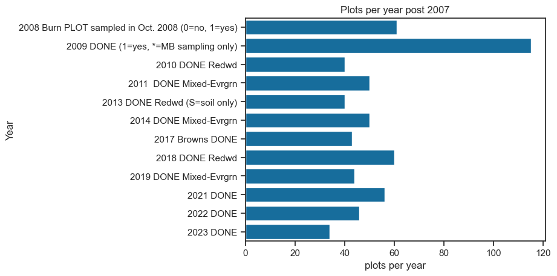

```python
df_year = df_plot.filter(regex="(?i)big sur|Original Sample|Oct. 2008|done")
df_year = df_year.rename(columns={
    df_year.columns[0] : 'BS_plot'
})
df_year_final = pd.melt(df_year, id_vars=['BS_plot'],  value_vars=df_year.iloc[:,2:], var_name='Year',
                        value_name='Yes/No')
df_year_final['Yes/No'].value_counts(dropna=False)
df_inv_year = df_year_final[
    df_year_final['Yes/No'] == '1'
    ]
confirm = df_inv_year['BS_plot'].nunique()
print(f"confirms query only 171 revisited from 2008 on-")
dfSum = df_inv_year.groupby('Year')['Yes/No'].size().reset_index(name='plots per year')
print("breakdown of the amount of plots per year")
sns.barplot(dfSum, y='Year', x='plots per year')
plt.title('Plots per year post 2007')
```

#### Disturbance grouping and distributions

Given data provided in the plot spreadsheet, add columns with fire scar boundary name, presence of p.ram, presence of fire.

```
now that burn scar is attached, we can see where the sites were visited each year post 2007 --
```

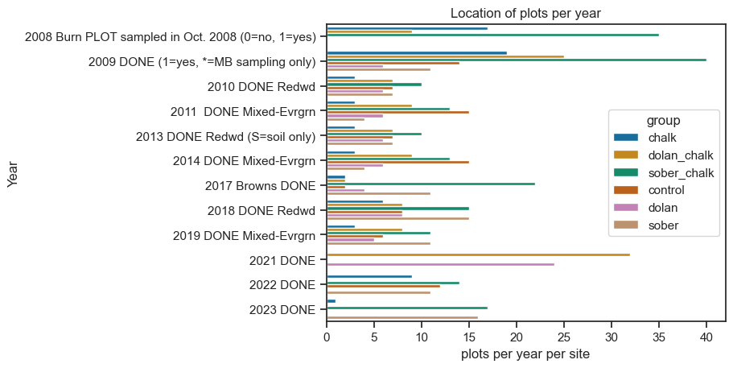

```python
# isolate data for if burned and p.ram detection year
df_burnPlot = df_plot.filter(regex="(?i)Big Sur|burned|1st P.ram|elevation|slope").iloc[:,[0,1,2,3,5,6,8]]
# create column with binary 0-1 for if p.ram is present given value in p. ram detection year
df_burnPlot['p.ram'] = ((pd.to_numeric(df_burnPlot['1st P.ram Dection'], errors='coerce').fillna(0) != 0).astype(int))
#convert other columns into numeric, fill na's with 0
cols_to_convert = df_burnPlot.columns[1:]  # everything except first and last
df_burnPlot[cols_to_convert] = df_burnPlot[cols_to_convert].apply(pd.to_numeric, errors='coerce').fillna(0).astype(int)
# copy df for fire status, add fire status given values for burned 2008, 2016, 2020 binary
df_burn = df_burnPlot.copy()
col1 = df_burn.iloc[:, 1]
col2 = df_burn.iloc[:, 2]
col3 = df_burn.iloc[:, 3]
conditions = [
    (col1 == 1) & (col2 == 0) & (col3 == 0),  # dolan
    (col1 == 0) & (col2 == 1) & (col3 == 0),  # sober
    (col1 == 0) & (col2 == 0) & (col3 == 1),  # chalk
    (col1 == 1) & (col2 == 0) & (col3 == 1),  # dolan_chalk
    (col1 == 0) & (col2 == 1) & (col3 == 1),  # sober_chalk
    (col1 == 0) & (col2 == 0) & (col3 == 0)   # control
]
labels = ['dolan', 'sober', 'chalk', 'dolan_chalk', 'sober_chalk', 'control']
df_burn['group'] = np.select(conditions, labels, default='unknown')
df_burn.columns.values[0] = 'BS_plot'
df_burn = df_burn.rename(columns = {df_burn.columns[4]: 'elevation', df_burn.columns[5]: 'slope' })
df_burn_year = df_burn.iloc[:,[0,-1]]
dfYearBurn = pd.merge(df_inv_year, df_burn_year, on='BS_plot', how='left')
dfTot = dfYearBurn.groupby(['Year', 'group'])['Yes/No'].size().reset_index(name='plots per year per site')
print("now that burn scar is attached, we can see where the sites were visited each year post 2007 --")
sns.barplot(dfTot, x='plots per year per site', y='Year', hue='group')
plt.title("Location of plots per year")
plt.show()
```

[output not shown]

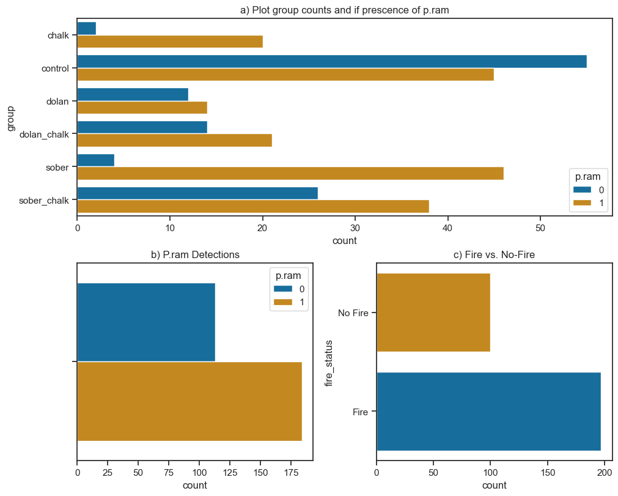

```python
# CAN BE CONDENSED
# group for data visualization
plot_data = []
for name,df in df_burn.groupby('group'):
    counts = df['p.ram'].value_counts().reset_index() # need to count
    counts.columns = ['p.ram', 'count']
    counts['group'] = name
    if 0 not in counts['p.ram'].values:
        counts = pd.concat([counts, pd.DataFrame({'p.ram': [0], 'count': [0], 'group': [name]})])
    if 1 not in counts['p.ram'].values:
        counts = pd.concat([counts, pd.DataFrame({'p.ram': [1], 'count': [0], 'group': [name]})])
    plot_data.append(counts)
# Combine all into one dataframe
plot_df = pd.concat(plot_data, ignore_index=True)
plot_df = plot_df.sort_values(['group', 'p.ram']).reset_index(drop=True)
## SEE ABOVE
#multi plot to see groups
fig = plt.figure(constrained_layout=True, figsize=(10, 8))
gs = fig.add_gridspec(2, 2)
ax_top = fig.add_subplot(gs[0, :])
#plot for multiple disturbances
print("using all 280 plots, we visualize burn scar, p ram presence and fire presence counts")
sns.barplot(data=plot_df, x='count', y='group',  hue='p.ram', ax=ax_top)
ax_top.set_title('a) Plot group counts and if prescence of p.ram')
#plot just comparing p.ram
p = plot_df.groupby('p.ram').sum().reset_index()
ax_bl = fig.add_subplot(gs[1, 0])
sns.barplot(data=p,  x='count', hue='p.ram', ax=ax_bl)
ax_bl.set_title('b) P.ram Detections')
# plot for comparing fire/no-fire
ax_br = fig.add_subplot(gs[1, 1])
# Define fire/no-fire groups
fire_groups = ['dolan', 'sober', 'chalk', 'dolan_chalk', 'sober_chalk']
# Add a fire_status column
df_burn['fire_status'] = np.where(df_burn['group'].isin(fire_groups), 'Fire', 'No Fire')
# Compute total counts per fire_status
summary = df_burn.groupby('fire_status')['p.ram'].count().sort_index().reset_index()
summary.rename(columns={'p.ram': 'count'}, inplace=True)
order = ['No Fire', 'Fire']
sns.barplot(data=summary, y='fire_status', x='count', hue='fire_status', ax=ax_br, order=order)
ax_br.set_title('c) Fire vs. No-Fire')
plt.show()
```

### How many redwoods have died since plot implementation?

Want to track redwood stem counts from 2006 to 2023 only in long-term plots. Things to consider,

- Are the amount of plots/trees inventoried variable from year to year?
- How does this impact results?

#### 1. Using stem count query data to see changes in mortality rates over time

Use stem count data provided by the spreadsheet [here](https://docs.google.com/spreadsheets/d/1v8svlbehpm1javFmeWQUJVsj88BfvcI0/edit?gid=1129755407#gid=1129755407).

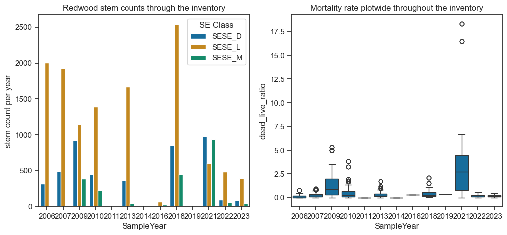

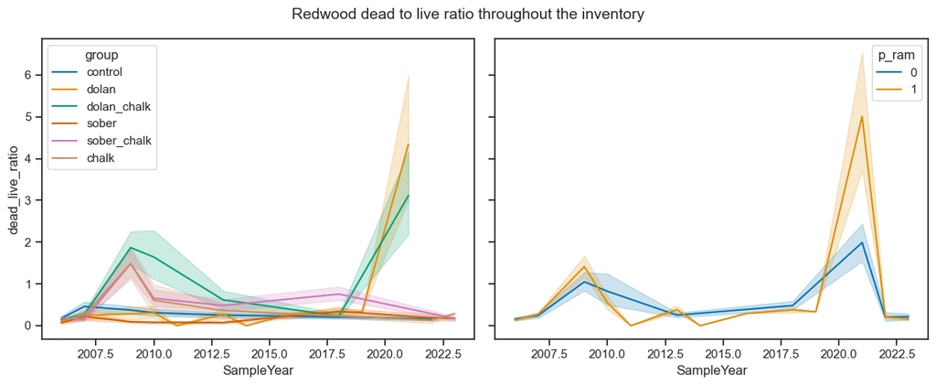

```
Our most extreme plot:
     BS_plot  SampleYear  p_ram        group fire_status  elevation  slope  \
785    BS611        2021      1  dolan_chalk        Fire        378     35
1601   BS611        2021      1  dolan_chalk        Fire        378     35
2417   BS611        2021      1  dolan_chalk        Fire        378     35

      dead_live_ratio SE Class  stem_count
785           18.3333   SESE_D          55
1601          18.3333   SESE_L           3
2417          18.3333   SESE_M          26
```

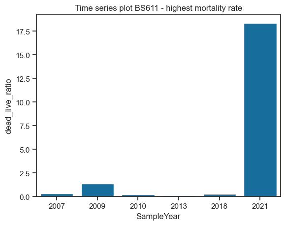

```python
df_stem = bs_data['stem_species']
df_redwood = df_stem.filter(regex="(?i)Plot|Sample|SESE") #only select plot#, sample year, SESE columns
df_redwood.columns.values[0] = 'BS_plot'
# merge on common BS_plot. use left merge to make sure stem count plot's present
df_temp = pd.merge(df_redwood, df_burn, on='BS_plot', how='left')
df_temp['dead_live_ratio'] = (df_temp['SESE_D']) / (df_temp['SESE_L'])

# need to pivot table so values for SESE_D, L, M are rows called stem_count with SE class D, L, M
df_redwood_final = pd.melt(df_temp, id_vars=['BS_plot', 'SampleYear', 'p.ram','group','fire_status', 'elevation', 'slope','dead_live_ratio'],
                           value_vars=['SESE_D', 'SESE_L', 'SESE_M'],
                           var_name="SE Class", value_name="stem_count")
df_redwood_final = df_redwood_final.rename(columns={'p.ram': 'p_ram'})
dfSumsYear = df_redwood_final.groupby(['SampleYear', 'SE Class'])['stem_count'].sum().reset_index(name='stem count per year')
fig, axes = plt.subplots(1, 2, figsize=(12, 5), sharey=False)
sns.barplot(dfSumsYear, x='SampleYear', y='stem count per year', hue='SE Class', ax=axes[0])
axes[0].set_title('Redwood stem counts through the inventory')
df_redwood_final = df_redwood_final.replace([np.inf, -np.inf], np.nan)
df_redwood_final = df_redwood_final.dropna()
df_redwood_final['dead_live_ratio'] = (
    df_redwood_final['dead_live_ratio']
    .replace([np.inf, -np.inf], np.nan)
    .astype(float)
)
sns.boxplot(
    df_redwood_final.dropna(subset=['dead_live_ratio']),
    x='SampleYear',
    y='dead_live_ratio', ax = axes[1]
)
axes[1].set_title('Mortality rate plotwide throughout the inventory')
plt.show()
fig, axes = plt.subplots(1, 2, figsize=(12, 5), sharey=True)
sns.lineplot(df_redwood_final, x='SampleYear', y='dead_live_ratio', hue='group', ax=axes[0])
sns.lineplot(df_redwood_final, x='SampleYear', y='dead_live_ratio', hue='p_ram', ax=axes[1])
plt.tight_layout()
fig.suptitle('Redwood dead to live ratio throughout the inventory', fontsize=14, y=0.97)
plt.tight_layout(rect=[0, 0, 1, 1])
fig.savefig('./mortalityTrend.png')
plt.show()
max_ratio = df_redwood_final['dead_live_ratio'].max()
high = df_redwood_final[
    df_redwood_final['dead_live_ratio'] == max_ratio
]
print('Our most extreme plot:')
print(high)
timeMort = df_redwood_final[
    df_redwood_final['BS_plot'] == 'BS611']
sns.barplot(timeMort, x='SampleYear', y='dead_live_ratio')
plt.title('Time series plot BS611 - highest mortality rate')
plt.show()
```

**Do we have inconsistencies due to data collection?**  
**Is this consistent with what we know about the severity of the Chalk and Dolan fires?**  
**Is the dead to live stem ratio a good metric?**

#### General Linear Model

Trying to see influence of sample year, p.ram, fire status, burn scar or topography on dead live ratio.  
Need to create new column with fire presence status dependent on the year of inventory/burn scar.

```python
col1 =df_redwood_final['SampleYear']
col2 = df_redwood_final['group']
conditions = [
    (col2 == 'control'), #plots with control group have fire = 0
    #chalk, chalk_dolan, sober_chalk group
    (col1 > 2008) & (col2 == 'chalk'), # plots greater than 2008 have fire =1
    (col1 < 2008) & (col2 == 'chalk'),
    (col1 > 2008) & (col2 == 'dolan_chalk'), # plots greater than 2008 have fire =1
    (col1 < 2008) & (col2 == 'dolan_chalk'),
    (col1 > 2008) & (col2 == 'sober_chalk'), # plots greater than 2008 have fire =1
    (col1 < 2008) & (col2 == 'sober_chalk'),
    #sober group
    (col1 > 2016) & (col2 == 'sober'), # plots greater than 2016 have fire =1
    (col1 < 2016) & (col2 == 'sober'),
    # dolan, dolan chalk group
    (col1 > 2020) & (col2 == 'dolan'), # plots greater than 2020 have fire =1
    (col1 < 2020) & (col2 == 'dolan')
]
labels = ['0', '1', '0','1', '0', '1', '0', '1', '0', '1', '0']
df_redwood_final['fire_presence'] = np.select(conditions, labels, default='unknown')
dfTest = df_redwood_final[
    (df_redwood_final['group'] == 'dolan') & (df_redwood_final['SampleYear'] > 2015)
    ]
print(f"testing to see if fire presence query was successful {dfTest.head(2)}")
```

```
testing to see if fire presence query was successful    BS_plot  SampleYear  p_ram  group fire_status  elevation  slope  \
40   BS038        2021      1  dolan        Fire        553     33
90   BS058        2018      0  dolan        Fire        744     25

    dead_live_ratio SE Class  stem_count fire_presence
40           6.6667   SESE_D          20             1
90           0.4122   SESE_D          54             0
```

```python
print('log transform dead to live ratio to see how it effects model performance')
#ln(1+y) - can see it's best if there are 0 values
df_redwood_final['logDLratio'] = np.log1p(df_redwood_final['dead_live_ratio'])
#df_redwood_final['log10DLratio'] = np.log10(df_redwood_final['dead_live_ratio'])
```

```
log transform dead to live ratio to see how it effects model performance
```

```python
# for continuous y data and dead-live-ratio
def glm(formula, data):
    ols_model = smf.ols(formula= formula, data=data).fit()
    # Type II (adjusted) sums of squares
    anova_results = anova_lm(ols_model, typ=2)  # typ=2 = adjusted sums of squares
    print("annova results for  p ram presence, burn scar :")
    print(anova_results)
    cont_model = smf.glm(formula=formula, data=data, family=sm.families.Gaussian()).fit() #continuous y variable?
    y_fitted = cont_model.predict(data)
    y_obs = data['logDLratio']
    residuals = y_obs-y_fitted
    r2 = r2_score(y_obs, y_fitted)
    print(cont_model.summary())
    print("R²:", r2)
    # Residuals vs Time plot
    plt.figure(figsize=(6,4))
    plt.scatter(data['SampleYear'], residuals, alpha=0.6)
    plt.axhline(0, color='red', linestyle='--', lw=2)
    plt.ylabel('Residuals (Observed - Fitted)')
    plt.title('Residuals vs Time')
    plt.grid(True)
    plt.show()
    '''
    plt.figure(figsize=(4,4))
    plt.scatter(data['dead_live_ratio'], y_fitted, alpha=0.6)
    plt.plot([data['dead_live_ratio'].min(), data['dead_live_ratio'].max()],
         [data['dead_live_ratio'].min(), data['dead_live_ratio'].max()],
         'r--', lw=2)
    plt.xlabel('Observed dead/live ratio')
    plt.ylabel('Fitted dead/live ratio')
    plt.title('Residual Plot')
    plt.grid(True)
    plt.show()
    '''
    '''
    effects_table = pd.DataFrame({
    'Coefficient': cont_model.params,
    'Std_Error': cont_model.bse,
    'z_value': cont_model.tvalues,       # For GLM with Gaussian, t-values
    'p_value': cont_model.pvalues,
    'Lower_95%': cont_model.conf_int()[0],
    'Upper_95%': cont_model.conf_int()[1]
    })
    # Optional: sort by absolute effect size
    effects_table['abs_coef'] = effects_table['Coefficient'].abs()
    effects_table = effects_table.sort_values(by='abs_coef', ascending=False).drop(columns='abs_coef')
    print(effects_table)
    '''
```

```
distribution of the dependent variable - log(dead to live ratio)
```

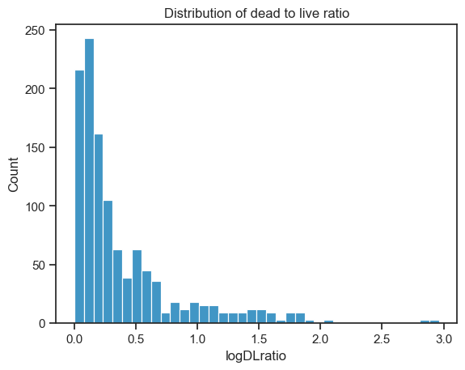

[output not shown]

[output cut: 216 more lines]

```
C(SampleYear)[T.2023]:C(p_ram)[T.1]               0.0265      0.133      0.200      0.841      -0.233       0.286
C(SampleYear)[T.2007]:C(fire_presence)[T.1]            0          0        nan        nan           0           0
C(SampleYear)[T.2009]:C(fire_presence)[T.1]       0.3763      0.052      7.275      0.000       0.275       0.478
C(SampleYear)[T.2010]:C(fire_presence)[T.1]       0.0022      0.069      0.032      0.975      -0.133       0.137
C(SampleYear)[T.2011]:C(fire_presence)[T.1]            0          0        nan        nan           0           0
C(SampleYear)[T.2013]:C(fire_presence)[T.1]      -0.1443      0.069     -2.103      0.035      -0.279      -0.010
C(SampleYear)[T.2014]:C(fire_presence)[T.1]            0          0        nan        nan           0           0
C(SampleYear)[T.2016]:C(fire_presence)[T.1]            0          0        nan        nan           0           0
C(SampleYear)[T.2018]:C(fire_presence)[T.1]      -0.0804      0.057     -1.415      0.157      -0.192       0.031
C(SampleYear)[T.2019]:C(fire_presence)[T.1]            0          0        nan        nan           0           0
C(SampleYear)[T.2021]:C(fire_presence)[T.1]       0.2898      0.037      7.774      0.000       0.217       0.363
C(SampleYear)[T.2022]:C(fire_presence)[T.1]      -0.1583      0.069     -2.309      0.021      -0.293      -0.024
C(SampleYear)[T.2023]:C(fire_presence)[T.1]      -0.1138      0.098     -1.164      0.244      -0.305       0.078
=================================================================================================================
R²: 0.7700884117544126
```

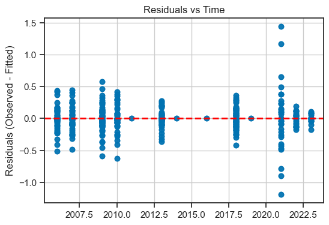

```
looking for interactions...
```

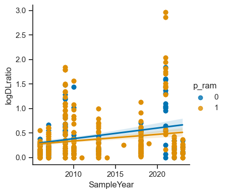

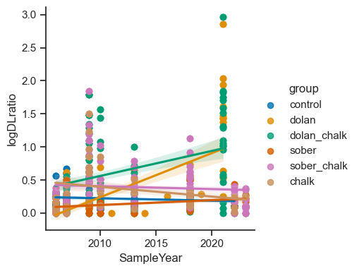

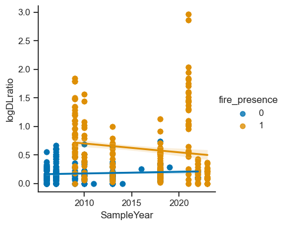

```python
print('distribution of the dependent variable - log(dead to live ratio)')
sns.histplot(df_redwood_final, x='logDLratio')
plt.title('Distribution of dead to live ratio')
plt.show()
eq = 'logDLratio ~  C(SampleYear) + C(fire_presence) + C(p_ram) + C(group) + C(elevation) + C(slope) +\
(C(SampleYear):C(group)) + (C(SampleYear):C(p_ram)) + (C(SampleYear):C(fire_presence))'
data = df_redwood_final
glm_fire = glm(eq, data)
print('looking for interactions...')
sns.lmplot(data=df_redwood_final, x='SampleYear',y='logDLratio',hue='p_ram', height=4)
plt.show()
sns.lmplot(data=df_redwood_final, x='SampleYear',y='logDLratio', hue='group',height=4)
plt.show()
sns.lmplot(data=df_redwood_final, x='SampleYear',y='logDLratio', hue='fire_presence',height=4)
plt.show()
```

#### Tree Database

Second attempt using the tree inventory dataset located [here](https://docs.google.com/spreadsheets/d/1HnFcAt-QIB9nOsEm94CMsk8XmoRtvoFf/edit?gid=1239576248#gid=1239576248).

```python
df_tree = bs_data['tree_data'].filter(regex="(?i)BS|species|Sample|DBH|status|basal|epicor|permanent")
df_red = df_tree[
    (df_tree['Species'] == "SESE") | (df_tree['Species'] == "LIDE") | (df_tree['Species'] == "UMCA") |
    (df_tree['Species'] == "CETH")
    ]
df_red = df_red.rename(columns={'BSPlotNumber': 'BS_plot'})
df_red_groups = pd.merge(df_red, df_burn, on='BS_plot', how='left')
```

**How has basal area of live stems changed through time for redwood, tanoak, bay laurel and ceanothus?**

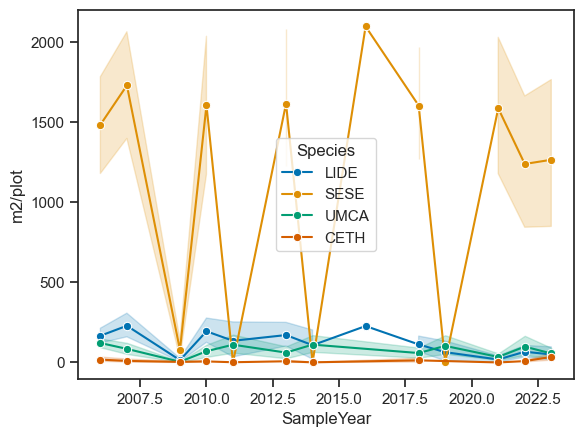

```python
dfStudy = df_red_groups.iloc[:,[0,1,2,10,14,18,19,21,22,23]].copy()
dfStudy['basal area'] = (0.005454 * (dfStudy['DBH'] **2))
dfLive = dfStudy[dfStudy['Status'] == 'L']
dfLiveYear = dfLive.groupby(['BS_plot','SampleYear', 'Species'])['basal area'].sum().reset_index(name='total ba')
dfLiveYear['m2/plot'] = dfLiveYear['total ba'] / 0.2 #20th of 1ha
sns.lineplot(dfLiveYear, x='SampleYear', y='m2/plot', hue='Species', marker='o')
```

##### How much data is available, how big and how many redwoods are present?

```
Amount of permanently tagged trees: 371
```

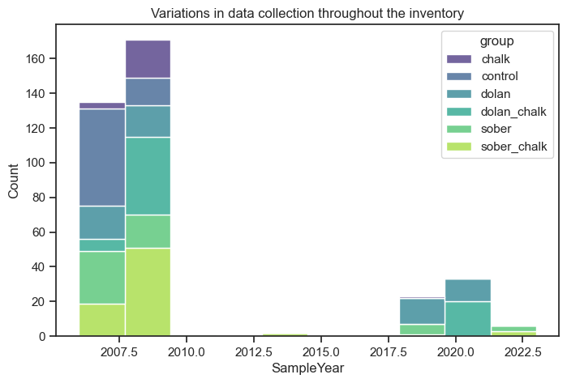

[figure not shown]

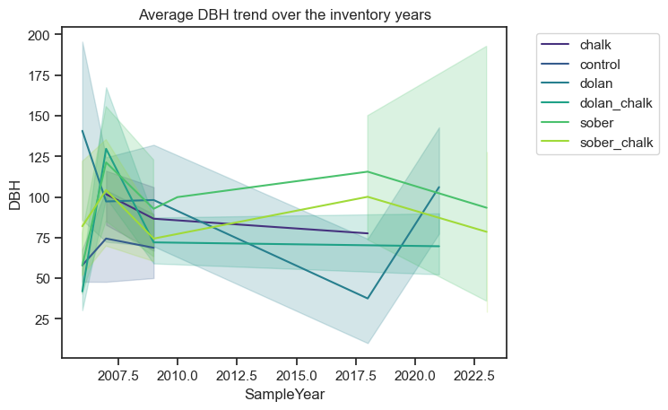

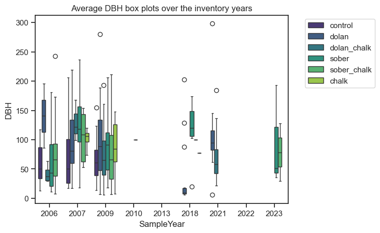

```python
long_term_tree = df_perm_red['PermanentTagNumber'].nunique()
print(f"Amount of permanently tagged trees: {long_term_tree}")
df_tree_mean = df_perm_red.groupby('PermanentTagNumber').agg({'DBH':'mean', 'group':'first', 'Status': 'first', 'SampleYear':'first'}).sort_values(by='group').reset_index()
plt.figure(figsize=(8,5))
sns.histplot(df_tree_mean, x='SampleYear', hue='group', multiple='stack',bins=10)
plt.title("Variations in data collection throughout the inventory")
plt.figure(figsize=(8,5))
sns.histplot(data=df_tree_mean, x='DBH', hue='group', multiple='stack')
plt.title("Median DBH distributions per fire group (median of unique tagged trees)")
plt.show()
sns.lineplot(data=df_tree_mean, x='SampleYear', y='DBH', hue='group')
plt.title("Average DBH trend over the inventory years")
plt.legend(bbox_to_anchor=(1.05, 1), loc='upper left')
plt.show()
sns.boxplot(data=df_tree_mean, x='SampleYear', y='DBH', hue='group')
plt.title("Average DBH box plots over the inventory years")
plt.legend(bbox_to_anchor=(1.05, 1), loc='upper left')
plt.show()
```

### Comparing DBH to Canopy Height

```
Number of trees with height data: 37
   Parameter   Value
0      Slope  0.2295
1  Intercept 12.1253
2  R-squared  0.6381
3    P-value  0.0000
4  Std Error  0.0292
```

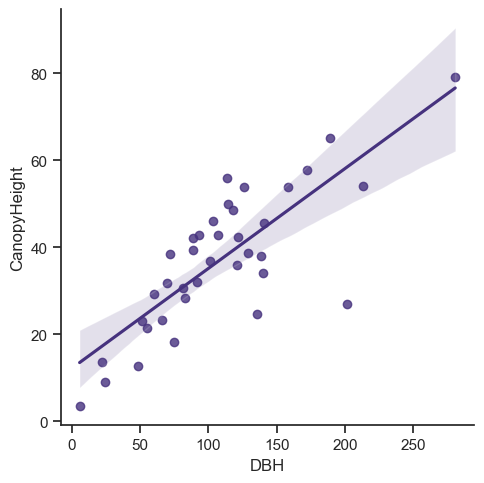

```python
tag = df_perm_red['CanopyHeight'].notnull().sum()
print(f"Number of trees with height data: {tag}")
sns.lmplot(data=df_perm_red, x='DBH', y='CanopyHeight')
df_clean = df_perm_red.dropna(subset=['DBH', 'CanopyHeight'])
x = df_clean['DBH']
y = df_clean['CanopyHeight']
slope, intercept, r_value, p_value, std_err = linregress(x, y)
# Create a raw table as a DataFrame
regression_table = pd.DataFrame({
    'Parameter': ['Slope', 'Intercept', 'R-squared', 'P-value', 'Std Error'],
    'Value': [slope, intercept, r_value**2, p_value, std_err]
})
print(regression_table)
```

**Not many records.**